# Exercise 1

Niclas Simmler

20.02.20

# Exercise 1.1

What is the expected period (time period of repetition) and the time step for the following timeseries:

1. Sunshine duration per month in Basel from 1990 to 2000. **Monthly**
2. Number of newborn babies in the city of Zurich per year from 2000 to 2011. **Annualy**
3. Number of reservations in a restaurant for every night during 4 weeks. **Daily**
4. Water runoff of a river. The data has been collected every day for 4 years. **Daily**

# Exercise 1.2

Using the data hstart.dat, we illustrate various methods for descriptive decomposition and elimination of trends. The data contains monthly data on the start of residential construction in the USA within the time frame of January 1966 to December 1974. The data have undergone some transformation unknown to us (perhaps an index over some baseline value has been calculated, or perhaps the data are to be read as x · 10? construction permits).

Make a time series plot. Is this a stationary time series? If not, what kind of non- stationarity is evident?

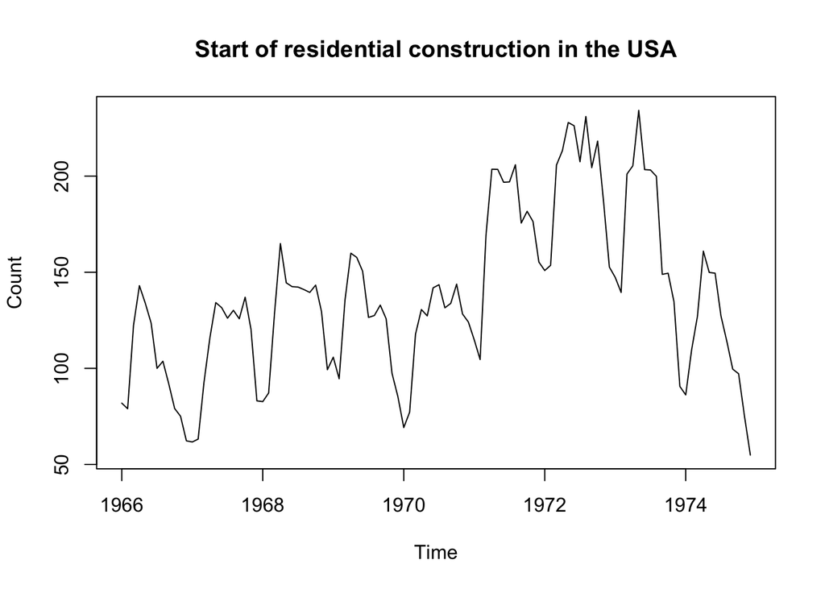

```r
start <- read.table('http://stat.ethz.ch/Teaching/Datasets/WBL/hstart.dat')
ts.obj <- ts(start, start = c(1966,1), freq = 12)
plot(ts.obj, ylab = 'Count', main = 'Start of residential construction in the USA')
```

It seems that there is an annual seasonal component present. There is a peak during summer and a low during winter.

# Exercise 1.3

Simulate timeseries according to the following models: a) Y1: Yt = Et−0.5·Et−1 ,where Et ∼N(0,1) i.i.d. E0 = 0

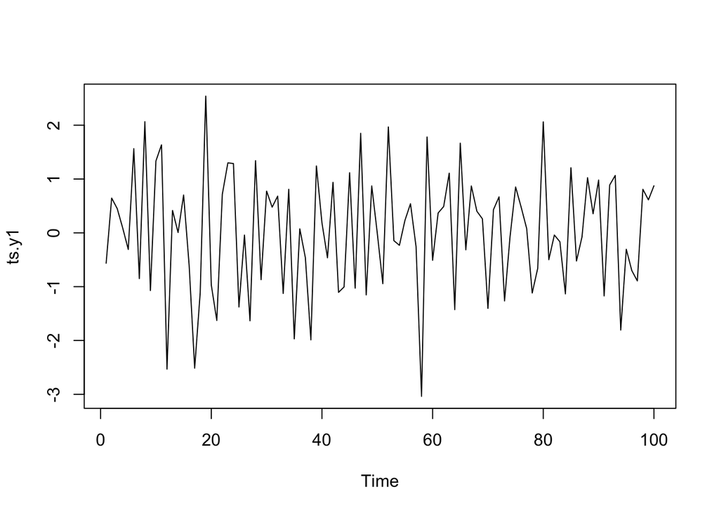

```r
# Define random seed
set.seed(42)
# Create Random Walker
Et <- ts(rnorm(101, 0, 1))
# Set Anchor
Et[1] <- 0
# Initialize y1
y1 <- 0

# Draw a point from Et
for (i in 2:length(Et)) {
    # Simulate change
    y1[i] <- Et[i] - 0.5 * Et[i-1]
}
# Skip 0 we defined earlier
y1 = y1[2:length(y1)]
# Create TS Obj
ts.y1 = ts(y1)
plot(ts.y1)
```

This timeseries seems to be stationary, since it is more or less evenly distributed around 0 (mean) and has a somewhat equal variance across time.

2. Y2: Yt =Yt−1+Et ,where Et ∼N(0,1) i.i.d.Y0 =0

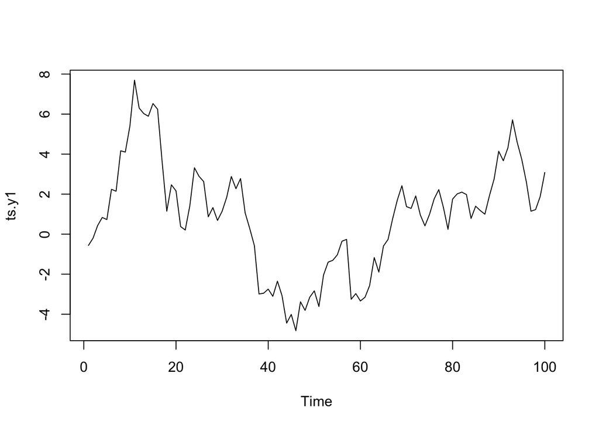

```r
# Define random seed
set.seed(42)
# Create Random Walker
Et <- ts(rnorm(101, 0, 1))
# Set Anchor
Et[1] <- 0
# Initialize y1
y1 <- 0

# Draw a point from Et
for (i in 2:length(Et)) {
    # Simulate change
    y1[i] <- y1[i-1] + Et[i]
}
# Skip 0 we defined earlier
y1 = y1[2:length(y1)]
# Create TS Obj
ts.y1 = ts(y1)
plot(ts.y1)
```

This timeseries seems not to be stationary as there is a varying variance across time.

3. Y3: Yt =0.5·Yt−1+Et ,where Et ∼N(0,1) i.i.d.Y0 =0

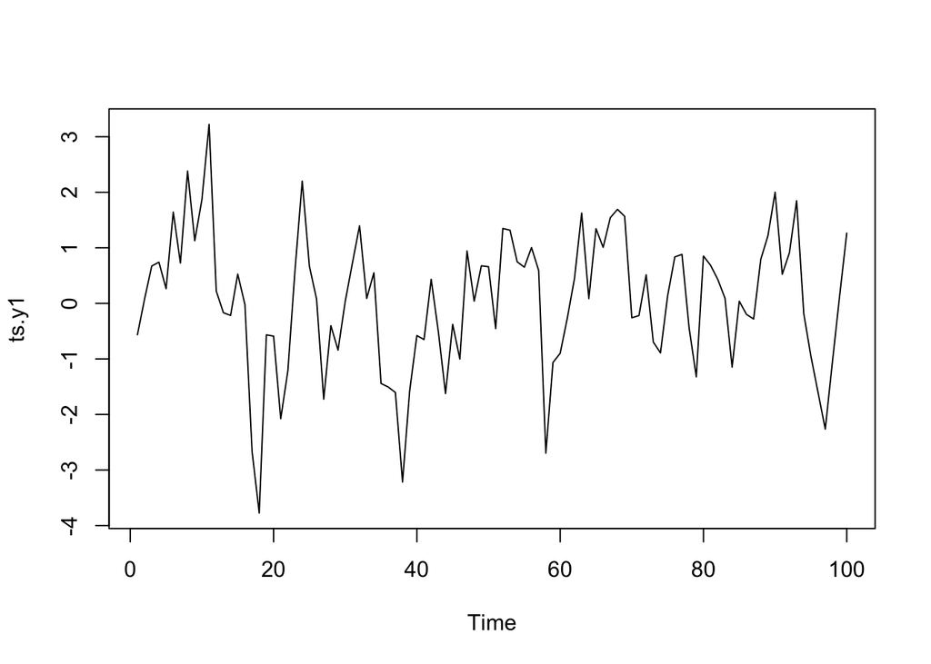

```r
# Define random seed
set.seed(42)
# Create Random Walker
Et <- ts(rnorm(101, 0, 1))
# Set Anchor
Et[1] <- 0
# Initialize y1
y1 <- 0

# Draw a point from Et
for (i in 2:length(Et)) {
    # Simulate change
    y1[i] <- 0.5*y1[i-1] + Et[i]
}
# Skip 0 we defined earlier
y1 = y1[2:length(y1)]
# Create TS Obj
ts.y1 = ts(y1)
plot(ts.y1)
```

4. Y4: Yt =Yt−1·Et ,where Et ∼U(0.95,1.05) i.i.d.Y0 =1

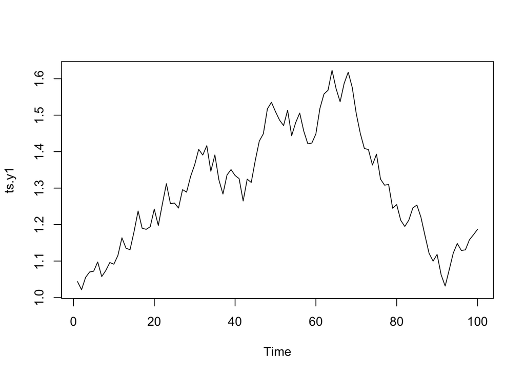

```r
# Define random seed
set.seed(42)
# Create Random Walker
Et <- ts(runif(101, 0.95, 1.05))
# Set Anchor
Et[1] <- 0
# Initialize y1
y1 <- 1

# Draw a point from Et
for (i in 2:length(Et)) {
    # Simulate change
    y1[i] <- y1[i-1] * Et[i]
}
# Skip 0 we defined earlier
y1 = y1[2:length(y1)]
# Create TS Obj
ts.y1 = ts(y1)
plot(ts.y1)
```

This timeseries seems not to be stationary as there is a varying variance across time.